# ¿Que hace a un corredor rápido?

Pablo León

April 13, 2016

Esta es una pregunta que preocupa, en mayor o menor medida, a todos aquellos que corren.

Y para la que no faltan respuestas, todos los runners tienen sus propias teorías y convicciones, y también están los sitios web, blogs y revistas que dan sus recomendaciones.

Como a mi también me interesa la pregunta (en sus variante ¿y como hizo toda esa gente para llegar antes que yó a la meta?) me propuse investigar el tema.

Voy a partir con lo más simple, tomar una carrera y comparar a los corredores según categoría de edad y género (sexo).

## La carrera

Los resultados son los de la carrera [Brooks #50](http://metachip.cl/?op=4&evento=243) de Vitacura ([segmento strava](https://www.strava.com/segments/1325221)). Es una carrera 10K (aproximadamente 9.85 km).

La carrera se corrió el 13 de Marzo del 2016, y tenemos resultados de 2322 corredores.

Los tiempos obtenidos (en minutos) se resumen de la siguiente forma:

```
##    Min. 1st Qu.  Median    Mean 3rd Qu.    Max.
##   31.15   51.07   58.32   59.26   66.91   93.65
```

## Por género

La cantidad de corredores por género es:

```
##    F    M
##  977 1345
```

Y los resultados son:

```
## $F
##    Min. 1st Qu.  Median    Mean 3rd Qu.    Max.
##   36.08   57.88   64.93   65.29   72.17   93.65
##
## $M
##    Min. 1st Qu.  Median    Mean 3rd Qu.    Max.
##   31.15   48.13   54.07   54.89   60.68   93.32
```

o dicho de otra forma:

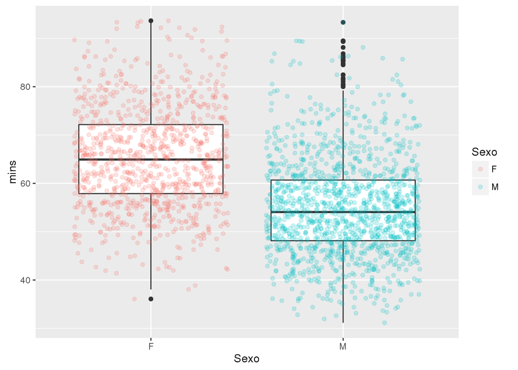

Mh … , hay tanto hombres como mujeres entre los más rápidos, y lo mismo en los más lentos.

Y sí, como era de esperar, en general los hombres son más rápidos que las mujeres.

## Por edad

Los resultados por categoría se dividen así:

| Categoria | Cant |
| --- | --- |
| 15 - 25 AÑOS | 312 |
| 26 - 35 AÑOS | 921 |
| 36 - 45 AÑOS | 676 |
| 46 - 55 AÑOS | 297 |
| 56 - 65 AÑOS | 91 |
| 66 A 70 AÑOS | 20 |
| 71 AÑOS Y + | 5 |

Y se ven así:

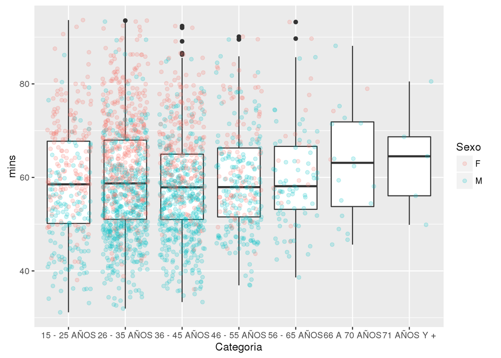

Ups, sorpresa. Todas las categorias entre 15 y 65 años tienen una media muy parecida.

#### ¡¿Quiere decir que no hay edad para correr?!

No exactamente, dandole un poco más de vueltas al asunto me encontré con algo cuando se separan los resultados de hombres y mujeres:

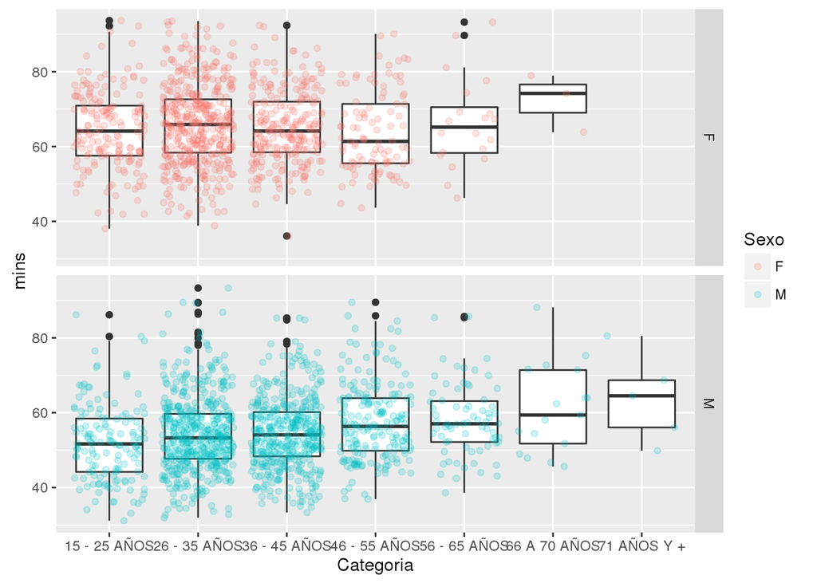

En los hombres la media aumenta con cada cambio de categoría. Es decir que a más joven, más rápido. Y el cambio parece bastante lineal, sin *plateaus*.

Lo que pasa en las mujeres es extraño. La categoría más rápida es la de “46 - 55 años”. Y se forma una especie de valle alrededor de esa categoría.

#### ¿¿¿???

Quizás esto ayude a entender:

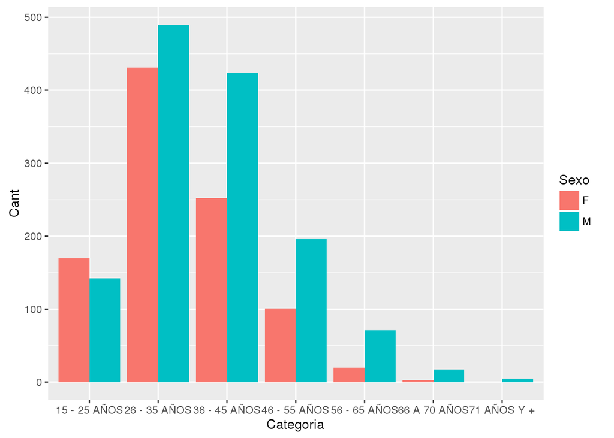

En la categoría de “15 - 26 años” la cantidad de mujeres es mayor que la de hombres! Pero de ahí en adelante la cantidad relativa a la de hombres baja con cada categoría.

Puede ser que en las siguientes categorías solo quedan compitiendo las corredoras más fuertes, y por eso su media baje en el tiempo.

### Conclusión

¡Me toca correr hoy, mañana seré más lento !